# Problem Set 4

Solutions

ECON 316 — Game Theory — Fall 2021

**Note**: Answers may be longer than I would deem sufficient on an exam. Some might vary slightly based on points of interest, examples, or personal experience. These suggested answers are designed to give you both the answer and a short explanation of why it is the answer.

# Concepts

## Question 1

#### Consider the simple hand game of “odds and evens,” where two players simultaneously hold out one or two of their fingers, and add up the sum. Suppose Player 1 has chosen Odds, and Player 2 has chosen Evens, such that the sum is odd, Player 1 wins; if the sum is even, Player 2 wins. Let a win be a payoff of 1, and a loss be a payoff of $-1$. The payoff table is below:

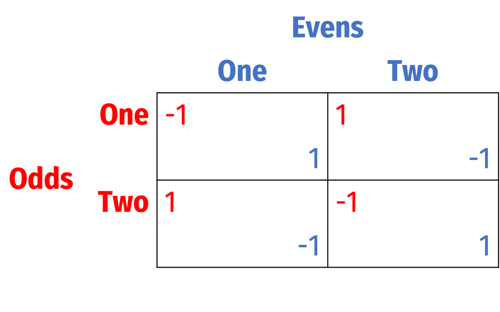

## Part A

#### Find any pure strategy Nash equilibria (PSNE).

There are no PSNE, in every outcome, at least one player can do better by changing their strategy. Best-response analysis also shows that in no outcome are both players playing a best response.

## Part B

#### Let p be the probability Odds plays One. Write out Evens’ expected payoffs of playing One and playing Two given this.

We must find the expected payoffs for Evens, given that Odds plays One with probability $p$.

To find Evens’ expected payoff for playing One, we add the two payoffs Evens gets for playing One, weighted by the probability Odds plays each of their strategies.

$$\begin{align*}
E[\color{blue}{One}]&=\color{blue}{1}(\color{red}{p})+(\color{red}{1-p})\color{blue}{-1} \\
E[\color{blue}{One}]&=p-1+p \\
E[\color{blue}{One}]&=2p-1\\
\end{align*}$$

To find Evens’ expected payoff for playing Two, we add the two payoffs Evens gets for playing Two, weighted by the probability Odds plays each of their strategies.

$$\begin{align*}
E[\color{blue}{Two}]&=\color{blue}{-1}(\color{red}{p})+(\color{red}{1-p})\color{blue}{1} \\
E[\color{blue}{Two}]&=-p+1-p \\
E[\color{blue}{Two}]&=1-2p\\
\end{align*}$$

## Part C

#### Solve for the optimal value of p that makes Evens indifferent between playing One and playing Two.

Here, we want Evens’ expected payoff from playing One to be equal to their expected payoff of playing Two, so we set their expected payoffs equal to each other, so we can find the value of $p$ that equalizes them.

$$\begin{align*}
E[\color{blue}{One}]&=E[\color{blue}{Two}] && \text{Opponent indifference principle}\\
2p-1&=1-2p && \text{Plugging in}\\
4p-1&=1 && \text{Adding }2p \text{ to both sides}\\
4p&=2 && \text{Adding 1 to both sides}\\
p&=0.50 && \text{Dividing both sides by 2}\\
\end{align*}$$

## Part D

#### Let q be the probability Evens plays One. Write out Odds’ expected payoffs of playing One and playing Two given this.

We must find the expected payoffs for Odds, given that Evens plays One with probability $q$.

To find Odds’ expected payoff for playing One, we add the two payoffs Odds gets for playing One, weighted by the probability Evens plays each of their strategies.

$$\begin{align*}
E[\color{red}{One}]&=\color{red}{-1}(\color{blue}{q})+(\color{blue}{1-q})\color{red}{1} \\
E[\color{red}{One}]&=-q+1-q \\
E[\color{red}{One}]&=1-2q\\
\end{align*}$$

To find Odds’ expected payoff for playing Two, we add the two payoffs Odds gets for playing Two, weighted by the probability Evens plays each of their strategies.

$$\begin{align*}
E[\color{red}{Two}]&=\color{red}{1}(\color{blue}{q})+(\color{blue}{1-q})\color{red}{-1} \\
E[\color{red}{Two}]&=q-1+q \\
E[\color{red}{Two}]&=2q-1\\
\end{align*}$$

## Part E

#### Solve for the optimal value of q that makes Odds indifferent between playing One and playing Two.

Here, we want Odds’ expected payoff from playing One to be equal to their expected payoff of playing Two, so we set their expected payoffs equal to each other, so we can find the value of $p$ that equalizes them.

$$\begin{align*}
E[\color{red}{One}]&=E[\color{red}{Two}] && \text{Opponent indifference principle}\\
1-2q&=2q-1 && \text{Plugging in}\\
1&=4q-1 && \text{Adding }2q \text{ to both sides}\\
2&=4q && \text{Adding 1 to both sides}\\
0.50&=q && \text{Dividing by 4}\\
\end{align*}$$

## Part F

#### What is the mixed strategy Nash equilibrium (MSNE) of this game?

**MSNE**: (p, q) = (0.50, 0.50).

In other words, Odds plays One 50% of the time and Two 50% of the time, and Evens plays One 50% of the time and Two 50% of the time.

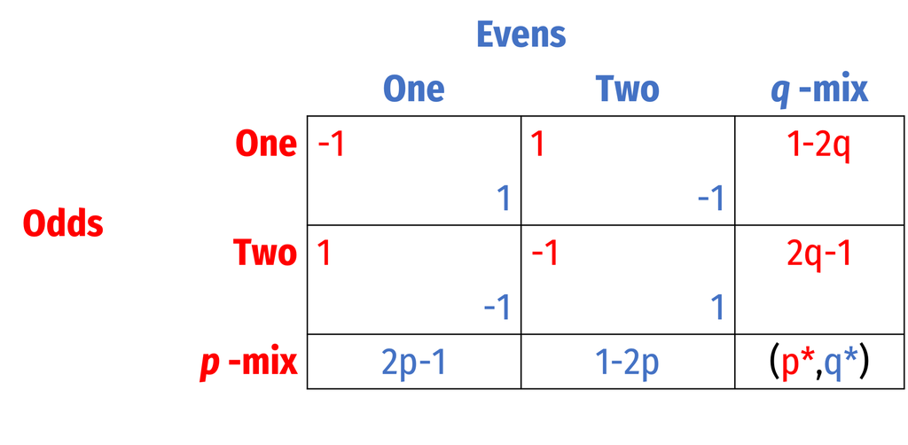

## Part G

#### What is each player’s expected payoff in MSNE?

Simply plug in $p=0.50$ into either equation from part b) to find Evens’ expected payoffs (they should be the same):

$$\begin{align*}
E[\color{blue}{One}]&=E[\color{blue}{Two}]\\
2p-1&=1-2p\\
2(0.50)-1&=1-2(0.50)\\
0&=0\\
\end{align*}$$

Evens’ expected payoff in the MSNE is 0.

Simply plug in $q=0.50$ into either equation from part d) to find Odds’ expected payoffs (they should be the same):

$$\begin{align*}
E[\color{red}{One}]&=E[\color{red}{Two}]\\
1-2q&=2q-1\\
1-2(0.50)-1&=2(0.50)-1\\
0&=0\\
\end{align*}$$

Odds’ expected payoff in the MSNE is 0.

## Question 2

You and your friend are deciding on a place to go for dinner, but are too busy to call or text one another. Each of you can go to the Chinese Restaurant or the Italian Restaurant – suppose you prefer Chinese and your friend prefers Italian.

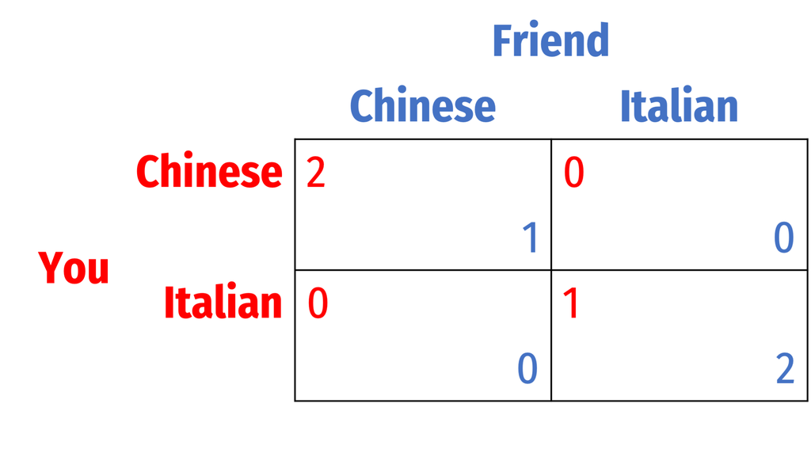

## Part A

#### Find any pure strategy Nash equilibria (PSNE).

This is a battle of the sexes type coordination game. The two PSNE are:

1. (Chinese, Chinese)
2. (Italian, Italian)

You prefer the first PSNE, Friend prefers the second PSNE.

## Part B

#### Let p be the probability You go to the Chinese restaurant. Write out your Friend’ expected payoffs of going to the Chinese and to the Italian restaurant given this.

We must find the expected payoffs for Friend, given that You go to Chinese with probability $p$.

To find Friend’s expected payoff for going to Chinese, we add the two payoffs Friend gets for going to Italian, weighted by the probability You go to each restaurant.

$$\begin{align*}
E[\color{blue}{Chinese}]&=\color{blue}{1}(\color{red}{p})+(\color{red}{1-p})\color{blue}{0} \\
E[\color{blue}{Chinese}]&=p\\
\end{align*}$$

To find Friend’s expected payoff for going to Italian, we add the two payoffs Friend gets for going to Italianweighted by the probability You go to each restaurant.

$$\begin{align*}
E[\color{blue}{Italian}]&=\color{blue}{0}(\color{red}{p})+(\color{red}{1-p})\color{blue}{2} \\
E[\color{blue}{Italian}]&=2-2p \\
\end{align*}$$

## Part C

#### Solve for the optimal value of p that makes your Friend indifferent between going to the Chinese and to the Italian restaurant.

Here, we want Friend’s expected payoff from going to Chinese to be equal to their expected payoff of going to Italian, so we set their expected payoffs equal to each other, so we can find the value of $p$ that equalizes them.

$$\begin{align*}
E[\color{blue}{Chinese}]&=E[\color{blue}{Italian}] && \text{Opponent indifference principle}\\
p&=2-2p && \text{Plugging in}\\
3p&=2 && \text{Adding }2p \text{ to both sides}\\
p&=\frac{2}{3} && \text{Dividing both sides by 3}\\
\end{align*}$$

## Part D

#### Let q be the probability your Friend goes to the Chinese restaurant. Write out Your’ expected payoffs of going to the Chinse and to the Italian restaurant given this.

We must find the expected payoffs for You, given that Friend goes to Chinese with probability $q$.

To find Your expected payoff for going to Chinese, we add the two payoffs You get for playing Chinese, weighted by the probability Friend goes to each restaurant.

$$\begin{align*}
E[\color{red}{Chinese}]&=\color{red}{2}(\color{blue}{q})+(\color{blue}{1-q})\color{red}{0} \\
E[\color{red}{One}]&=2q \\
\end{align*}$$

To find Your expected payoff for going to Italian, we add the two payoffs You get for going to Italian, weighted by the probability Friend goes to each restaurant.

$$\begin{align*}
E[\color{red}{Italian}]&=\color{red}{0}(\color{blue}{q})+(\color{blue}{1-q})\color{red}{1} \\
E[\color{red}{Italian}]&=1-q \\
\end{align*}$$

## Part E

#### Solve for the optimal value of q that makes You indifferent between going to the Chinese and to the Italian restaurant.

Here, we want Your expected payoff from going to Chinese to be equal to your expected payoff of going to Italian, so we set your expected payoffs equal to each other, so we can find the value of $q$ that equalizes them.

$$\begin{align*}
E[\color{red}{Chinese}]&=E[\color{red}{Italian}] && \text{Opponent indifference principle}\\
2q&=1-q && \text{Plugging in}\\
3q&=1 && \text{Adding }q \text{ to both sides}\\
q&=\frac{1}{3} && \text{Dividing both sides by 3}\\
\end{align*}$$

## Part F

#### What is the mixed strategy Nash equilibrium (MSNE) of this game?

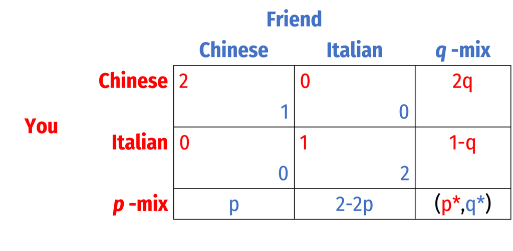

## Part G

#### What is each player’s expected payoff in MSNE?

Simply plug in $p=\frac{2}{3}$ into either equation from part b) to find Friend’} expected payoffs (they should be the same):

$$\begin{align*}
E[\color{blue}{Chinese}]&=E[\color{blue}{Italian}]\\
p&=2-2p\\
(\frac{2}{3})&=2-2(\frac{2}{3})\\
\frac{2}{3}&=\frac{2}{3}\\
\end{align*}$$

Friend’s expected payoff in the MSNE is $\color{blue}{\frac{2}{3}}$.

Simply plug in $q=\frac{1}{3}$ into either equation from part d) to find Your expected payoffs (they should be the same):

$$\begin{align*}
E[\color{red}{Chinese}]&=E[\color{red}{Italian}]\\
2q&=1-q\\
2(\frac{1}{3})&=1-(\frac{1}{3})\\
\frac{2}{3}&=\frac{2}{3}\\
\end{align*}$$

Your expected payoff in the MSNE is $\color{red}{\frac{2}{3}}$.

## Part H

#### Write out and draw each player’s best response function. Put $p$ on the horizontal axis and $q$ on the vertical axis. Label all equilibria appropriately. Label all equilibria on your graph. Hint: which expected payoff of your Friend’s strategies increases as $p$ increases (decreases)? Which expected payoff of Your strategies increases as $q$ increases (decreases)?

Let’s start with Friend’s best responses. A hint is to plug in numbers for $p$ that are smaller/larger than $p^*=\frac{2}{3}$ and see which strategy yields a higher expected payoff.

Let’s start with a smaller number, $\frac{1}{4}$:

$$\begin{align*}
E[\color{blue}{Chinese}]& \lessgtr E[\color{blue}{Italian}]\\
p & \lessgtr 2-2p\\
(\frac{1}{4}) &\lessgtr 2-2(\frac{1}{4}) \\
\frac{1}{4} &< \frac{6}{4} \\
\end{align*}$$

Thus, if $p<\frac{2}{3}$, Friend is better off going Italian}.

Now try plugging in a larger number, say $\frac{3}{4}$:

$$\begin{align*}
E[\color{blue}{Chinese}]& \lessgtr E[\color{blue}{Italian}]\\
p & \lessgtr 2-2p\\
(\frac{3}{4}) &\lessgtr 2-2(\frac{3}{4}) \\
\frac{3}{4} &> \frac{2}{4} \\
\end{align*}$$

Thus, if $p>\frac{2}{3}$, Friend is better off going Chinese}.

We can then construct Friend’s Best Response$=\begin{cases} Italian & \text{if }p<\frac{2}{3}\\ Indifferent & \text{if }p=\frac{2}{3}\\ Chinese & \text{if }p>\frac{2}{3}\\ \end{cases}$

Now do the same thing for Your best responses. We’ll again plug in numbers for $q$ that are smaller/larger than $q^*=\frac{1}{3}$ and see which strategy yields a higher expected payoff.

Let’s start with a smaller number, $\frac{1}{4}$:

$$\begin{align*}
E[\color{red}{Chinese}]& \lessgtr E[\color{red}{Italian}]\\
2q & \lessgtr1-q\\
2(\frac{1}{4}) &\lessgtr 1-(\frac{1}{4}) \\
(\frac{2}{4}) &<\frac{3}{4}\\
\end{align*}$$

Thus, if $q<\frac{1}{3}$, You are better off going Italian}.

Now try plugging in a larger number, say $\frac{1}{2}$:

$$\begin{align*}
E[\color{red}{Chinese}]& \lessgtr E[\color{red}{Italian}]\\
2q & \lessgtr 1-q\\
2(\frac{1}{2}) &\lessgtr 1-(\frac{1}{2}) \\
1 &>\frac{1}{2}\\
\end{align*}$$

Thus, if $q>\frac{1}{3}$, You are better off going Chinese.

We can then construct Your Best Response$=\begin{cases} Italian & \text{if }q<\frac{1}{3}\\ Indifferent & \text{if }q=\frac{1}{3}\\ Chinese & \text{if }q>\frac{1}{3}\\ \end{cases}$

This should make sense, since this is a coordination game–both of you want to end up at the same place. For each player, if there is a low probability the other player is going to Chinese, then you should go to Italian; if there is a high probability the other player is going to Chinese, you should go to Chinese.

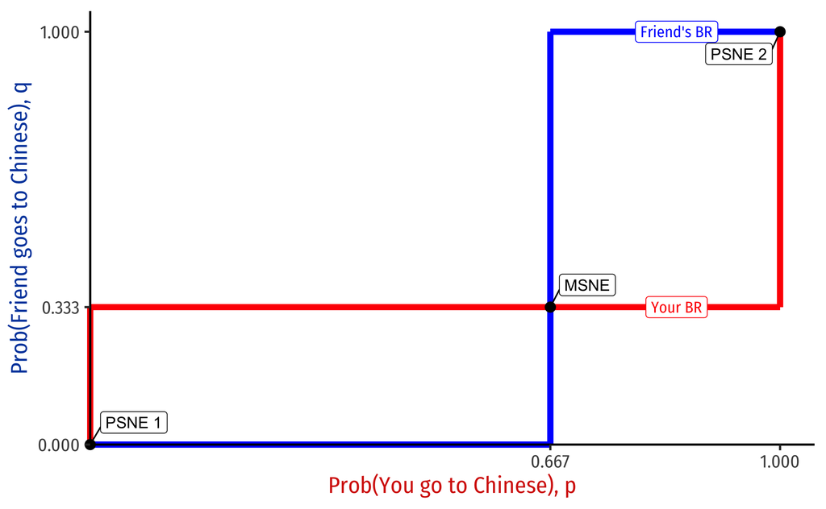

## Part I

#### Given your answers to the above questions, calculate the probability that both of you go to the Chinese restaurant and the probability that both of you go to the Italian restaurant. Hint: assume each person’s choice is independent.

Use the multiplication rule for independent events: $P(A \text{ and }B)=P(A) \times P(B)$

$$\begin{align*}
P(\text{You go to Chinese and Friend goes to Chinese})&=P(\text{You go to Chinese}) \times P(\text{Friend goes to Chinese})\\
P(\text{You go to Chinese and Friend goes to Chinese})&=p \times q\\
P(\text{You go to Chinese and Friend goes to Chinese})&=\frac{2}{3} \times \frac{1}{3}\\
P(\text{You go to Chinese and Friend goes to Chinese})&=\frac{2}{9}\\
\end{align*}$$

$$\begin{align*}
P(\text{You go to Italian and Friend goes to Italian})&=P(\text{You go to Italian}) \times P(\text{Friend goes to Italian})\\
P(\text{You go to Italian and Friend goes to Italian})&=(1-p) \times (1-q)\\
P(\text{You go to Italian and Friend goes to Italian})&=\frac{1}{3} \times \frac{2}{3}\\
P(\text{You go to Italian and Friend goes to Italian})&=\frac{2}{9}\\
\end{align*}$$

## Question 3

The chief of police is attempting to crack down on drunk driving, and is deciding whether to set up a sobriety checkpoint. Setting up a checkpoint always catches drunk driving, but costs the city resources. A partygoer can choose to drink Beer or Soda before driving home. Suppose the payoffs are as follows:

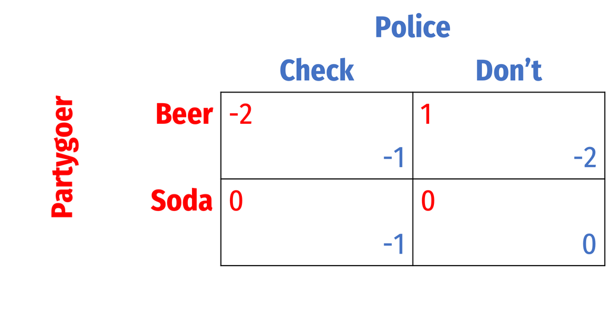

### Part A

#### Find the mixed strategy Nash equilibrium.

Let $p$ be the probability that Partygoer drinks Beer. The expected payoffs for Police are:

$$\begin{align*}
E[\color{blue}{Check}] &= \color{blue}{-1}(\color{red}{p})+\color{red}{(1-p)}\color{blue}{-1}\\
E[\color{blue}{Check}] &= -p-1+p\\
E[\color{blue}{Check}] &= -1\\
\end{align*}$$

$$\begin{align*}
E[\color{blue}{Don't}] &= \color{blue}{-2}(\color{red}{p})+\color{red}{(1-p)}\color{blue}{0}\\
E[\color{blue}{Don't}] &= -2p\\
\end{align*}$$

Police are indifferent at the $p$ where:

$$\begin{align*}
E[\color{blue}{Check}] &= E[\color{blue}{Dont}]\\
-1 &= -2p\\
\frac{1}{2} & = p\\
\end{align*}$$

Let $q$ be the probability that Police Checks. The expected payoffs for Partygoer are:

$$\begin{align*}
E[\color{red}{Beer}] &= \color{red}{-2}(\color{blue}{q})+\color{blue}{(1-q)}\color{red}{1}\\
E[\color{red}{Beer}] &= -2q+1-q\\
E[\color{red}{Beer}] &= 1-3q\\
\end{align*}$$

$$\begin{align*}
E[\color{red}{Soda}] &= \color{red}{0}(\color{blue}{q})+\color{blue}{(1-q)}\color{red}{0}\\
E[\color{red}{Soda}] &= 0\\
\end{align*}$$

Partygoer is indifferent at the $q$ where:

$$\begin{align*}
E[\color{red}{Beer}] &= E[\color{red}{Soda}]\\
1-3q &= 0\\
1 & = 3q\\
\frac{1}{3} &= q\\
\end{align*}$$

**MSNE**: (p, q)=($\color{red}{\frac{1}{2}}$, $\color{blue}{\frac{1}{3}}$).

In other words, Partygoer will drink Beer $\frac{1}{2}$ of the time and Soda $\frac{1}{2}$ of the time; Police will Check $\frac{1}{3}$ of the time and Don’t $\frac{2}{3}$ of the time.

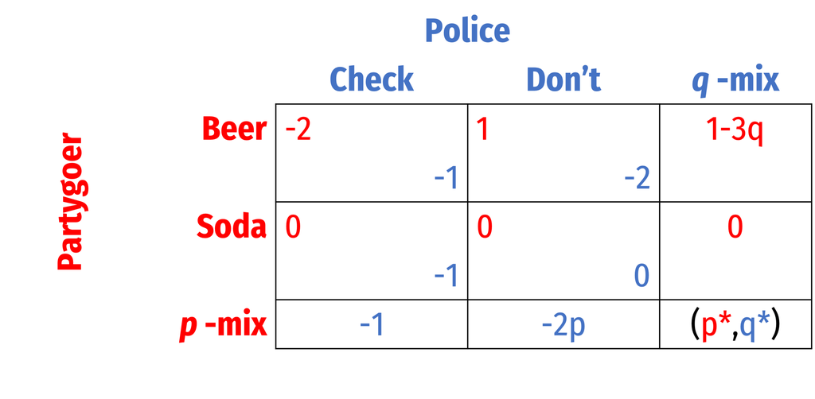

### Part B

#### What is each party’s expected value under the MSNE?

$$\begin{align*}
E[\color{blue}{Check}]&=E[\color{blue}{Don't}]\\
-1&=-2p\\
-1&=-2(\frac{1}{2})\\
-1&=-1\\
\end{align*}$$

Police’s expected payoff in the MSNE is $\color{blue}{-1}$.

$$\begin{align*}
E[\color{red}{Beer}]&=E[\color{red}{Soda}]\\
1-3q&=0\\
1-3(\frac{1}{3})&=0\\
0&=0\\
\end{align*}$$

Partygoer’s expected payoff in the MSNE is $\color{red}{0}$.